# SFJD 2014 Mean

This set of R scripts processes logger data for predictive stream temperature modeling Created: 21 Feb 2017 Used for all watersheds and all years by changing the basin names and year paths

Stage setting:

```r
library(timeSeries)
library(lattice)
library(foreign)
library(doBy)
library(qpcR)
library(pls)
library(boot)
library(Hmisc)
library(readxl)
library(lubridate)
library(zoo)
library(car)
library(gvlma)
library(ggplot2)
library(rgdal)
library(raster)
library(RColorBrewer)
library(classInt)
library(uuid)
   basin <- "SFJD"
  midBasin <- "SFJohnDay"
  longBasin <- "SouthForkJohnDay"
  yrPath <- "14"
  yearPath <- "2014"

  nameBasin <- "South Fork John Day" #this is from the Projects XML list of approved names

  dataPath <- "D:/OneDrive/work/GIS/8_day_1km_LST/LST_s12_"
  mainPath <- "D:/OneDrive/work/research/CHaMP/CHaMP_data/"
  metricPath <- "D:/Dropbox/StreamTemperatureModels/"

  var <- "Mn"
  longVar <- "Mean"
  dataVar <- "Mn8Day" #name of the variable in the logger data
  capVar <- "MEAN"

  modelPath <- paste0(mainPath, longBasin, "/", yearPath, "/", longVar, "/")
  gisPath <- "D:/OneDrive/work/research/CHaMP/GIS/coverages/"
```

This part reads the LST data and gap-fills using a cubic spline function

```r
  LST.in <- read.dbf(paste0(gisPath, "/", longBasin, "/", longBasin, "_", yrPath, "_LST.dbf"))
  PointID <- LST.in[,1]
  LST.in <- LST.in[,2:47]
  LST.in[LST.in<0.1] = NA
  LSTmeans <- colMeans(LST.in, na.rm=TRUE)

  LST.names<-colnames(LST.in)

  myFunc <- function(x)
    {
      if (is.na(x[1]))
      {
        x[1] <- LSTmeans[1]
      }
      x
    }

  LST.filled <- apply(LST.in, 1, function(x) myFunc(x))
  LST.filled <- as.data.frame(t(LST.filled))


  myFunc2 <- function(x)
    {
      if (is.na(x[46]))
      {
        x[46] <- x[43]
      }
      x
    }


  LST.filled <- apply(LST.filled, 1, function(x) myFunc2(x))
  LST.filled <- as.data.frame(t(LST.filled))

  myFunc3 <- function(x)
    {
      if (is.na(x[46]))
      {
        x[46] <- LSTmeans[46]
      }
      x
    }

  LST.filled <- apply(LST.filled, 1, function(x) myFunc3(x))
  LST.filled <- as.data.frame(t(LST.filled))

  tLST.in <- t(LST.filled)

  tLST.out <- na.spline(tLST.in)
  CLST <- tLST.out*0.02-273.15
  tCLST <- t(CLST)
  CLST.out <- as.data.frame(tCLST)


  CLST.out$PointID <- PointID
  colnames(CLST.out)[1:46] <- LST.names
```

Plot to look

```r
{plot(1:46, CLST.out[1149,1:46])
  points(1:46, CLST.out[562, 1:46], pch=16, col="blue")
  points(1:46, CLST.out[1000, 1:46], pch=16, col="green")
  points(1:46, CLST.out[1, 1:46], pch=16, col="red")
  points(1:46, CLST.out[800, 1:46], pch=16, col="lightblue")}
```

[output not shown]

Write it out

```r
  write.dbf(CLST.out, file = paste0(mainPath, longBasin, "/", "LST", yrPath, "_", basin, "_interp.dbf"))
```

This part calculates the zonal mean of the daily LST for each RCA

```r
out_Preds <- read.dbf(paste0(mainPath, longBasin, "/", "LST", yrPath, "_", basin, "_interp.dbf"))


  weights <- read.csv(paste0(mainPath, longBasin, "/", midBasin, "_rca_area_wgts.csv"), stringsAsFactors=FALSE)
  weights[weights$area_wgt<0.01, "area_wgt"] = 0.01

  rcas <- unique(unlist(weights$RCAID))
  rca_zonal <- matrix(ncol=46, nrow=length(rcas))


  l <- 1

  for(i in rcas)
    {
      pixels <- weights[weights$RCAID == i, "GRIDCODE"]
      wgts <- weights[weights$RCAID == i, "area_wgt"]

      for (j in 1:46)
      {
        daily <- out_Preds[out_Preds$PointID %in% pixels, j]
        zonal_mn <- weighted.mean(daily, wgts, na.rm = TRUE)
        rca_zonal[l,j] <- zonal_mn
      }
      l <- l+1
    }


  colnames(rca_zonal)[1:46] <- colnames(out_Preds)[1:46]
  rca_zonal <- as.data.frame(rca_zonal)
  rca_zonal$RCAID <- rcas
```

Plot to look

```r
{plot(1:46, rca_zonal[rca_zonal$RCAID==1436,1:46])
  points(1:46, rca_zonal[rca_zonal$RCAID==1151, 1:46], pch=16, col="blue")
  points(1:46, rca_zonal[rca_zonal$RCAID==636, 1:46], pch=16, col="green")
  points(1:46, rca_zonal[rca_zonal$RCAID==562, 1:46], pch=16, col="red")
  points(1:46, rca_zonal[800, 1:46], pch=16, col="lightblue")}
```

[output not shown]

Write out rca_zonal

```r
  write.dbf(rca_zonal, file = paste0("../", "LST", yrPath, "_", basin, "_RCA.dbf"))
```

Model building

```r
  Log.in <- read.csv(paste0("../../", basin, "_logger_8D_", yearPath, ".csv"), stringsAsFactors = FALSE)
```

[output not shown]

split data into seasonal subsets

```r
  NoNA.xyz <- read.csv(paste0(basin, "_", yearPath, "_8Day_", var, "_model_data.csv"), stringsAsFactors = FALSE)
```

[output not shown]

plot the data

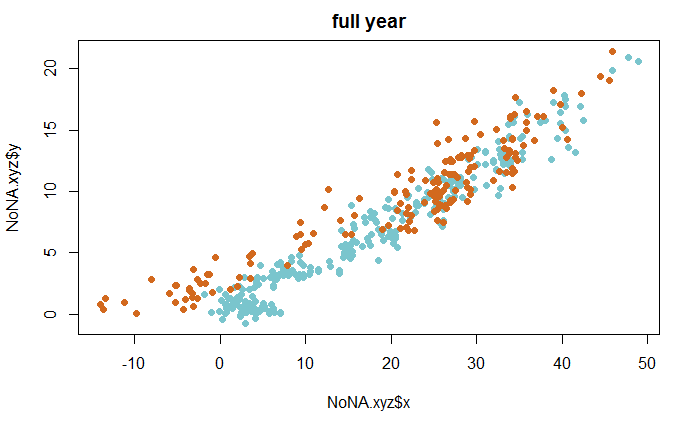

```r
  {plot(NoNA.xyz$x, NoNA.xyz$y, main = "full year")
  points(data.sp$x, data.sp$y, pch=16, col="cadetblue3")
  points(data.fall$x, data.fall$y, pch=16, col="chocolate")}
```

```r
NA
```

#### Full year models

```r
  y <- NoNA.xyz$y
  x <- NoNA.xyz$x
  z <- NoNA.xyz$z
  e <- NoNA.xyz$e

  mod <- lm(y ~ x + I(x^2) + e)
  sum_mod <- summary(mod)
  sum_mod
```

```
Call:
lm(formula = y ~ x + I(x^2) + e)

Residuals:
    Min      1Q  Median      3Q     Max
-4.3411 -1.0279 -0.1466  0.9574  5.9642

Coefficients:
              Estimate Std. Error t value Pr(>|t|)
(Intercept) -0.0997170  0.6426676  -0.155   0.8768
x            0.2241167  0.0159142  14.083   <2e-16 ***
I(x^2)       0.0040511  0.0004261   9.507   <2e-16 ***
e            0.0011866  0.0005021   2.363   0.0186 *
---
Signif. codes:  0 ‘***’ 0.001 ‘**’ 0.01 ‘*’ 0.05 ‘.’ 0.1 ‘ ’ 1

Residual standard error: 1.544 on 433 degrees of freedom
Multiple R-squared:  0.9109,    Adjusted R-squared:  0.9103
F-statistic:  1476 on 3 and 433 DF,  p-value: < 2.2e-16
```

Model prediction

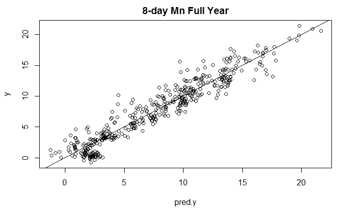

```r
  pred.y <- predict(mod)
  {plot(pred.y, y, main = paste0("8-day ", var, " Full Year"))
  abline(0,1)}
```

Model diagnostics

```r
  post_mod <- summary(lm(y ~ pred.y))
  gvmodel <- gvlma(mod)
  summary(gvmodel)
```

```r
  outlierTest(mod)
```

```r
  qqPlot(mod, main="QQ Plot Full Year")
```

Assumptions:

```r
plot(mod)
```

```r
  spreadLevelPlot(mod)
```

```r
  plot(pred.y, mod$residuals, main="Model diagnostics Full Year", xlab="Predicted", ylab="Residuals")
```

```r
  pressstat_sum <- PRESS(mod, verbose = "FALSE")
  RMSEP <- sqrt(mean((pressstat_sum$residuals)^2))

  library(pls)
  mod2 <- plsr(y ~ x + I(x^2) + e, validation = "LOO")
  p2 <- R2(mod2)
  detach("package:pls", unload=TRUE)

  coeffs <- as.matrix(coefficients(sum_mod))

  pred.out <- matrix(nrow=length(pred.y), ncol=5)
  pred.out[,1] <- y
  pred.out[,2] <- pred.y
  pred.out[,3] <- z
  pred.out[,4] <- "full year"
  pred.out[,5] <- yearPath
  colnames(pred.out) <- c("Y", "PredY", "JulDay", "Season", "Year")
  write.table (x=pred.out,append=T,row.names=F,file=paste0("jk_pred_v_y_", var, "_", basin, "_", yearPath, "_full_year.csv"),sep = ",", col.names=F)
```

```r
  fit <- lm(y~ pred.y)

  summary(fit)
```

Output tables formatting for coeffs and metrics

```r
  coeffs_out <- data.frame(Int=numeric(2), bLST=numeric(2), bLST2=numeric(2), bJul=numeric(2), bElev=numeric(2))
  metrics_out <- data.frame(r2=numeric(2), RMSE=numeric(2), p2=numeric(2), RMSEP=numeric(2), N_Sites=numeric(2), N=numeric(2))
  rownames(metrics_out) <- c("Spring", "Fall")
  rownames(coeffs_out) <- c("Spring", "Fall")
```

No Julday output

```r
  coeffs_out[1,1] <- coeffs[1,1]
  coeffs_out[1,2] <- coeffs[2,1]
  coeffs_out[1,3] <- coeffs[3,1]
  coeffs_out[1,4] <- 0
  coeffs_out[1,5] <- coeffs[4,1]

  metrics_out[1,1] <- sum_mod$adj.r.squared
  metrics_out[1,2] <- sum_mod$sigma
  metrics_out[1,3] <- p2$val[5]
  metrics_out[1,4] <- RMSEP
  metrics_out[1,5] <- length(unique(NoNA.xyz$SiteName))
  metrics_out[1,6] <- length(y)

  coeffs_out[2,1] <- coeffs[1,1]
  coeffs_out[2,2] <- coeffs[2,1]
  coeffs_out[2,3] <- coeffs[3,1]
  coeffs_out[2,4] <- 0
  coeffs_out[2,5] <- coeffs[4,1]

  metrics_out[2,1] <- sum_mod$adj.r.squared
  metrics_out[2,2] <- post_mod$sigma
  metrics_out[2,3] <- p2$val[5]
  metrics_out[2,4] <- RMSEP
  metrics_out[2,5] <- length(unique(NoNA.xyz$SiteName))
  metrics_out[2,6] <- length(y)
```

Write stuff out

```r
  write.table(x=coeffs_out, append=F,row.names=T, file = paste0("All_data_", basin, "_", yearPath, "_mod_coeffs_", var, ".csv"), sep = ",", col.names=T)

  write.table(x=metrics_out, append=F,row.names=T, file = paste0("All_data_", basin, "_", yearPath, "_mod_metrics_", var, ".csv"), sep = ",", col.names=T)
```

Spring/Fall models Spring data model

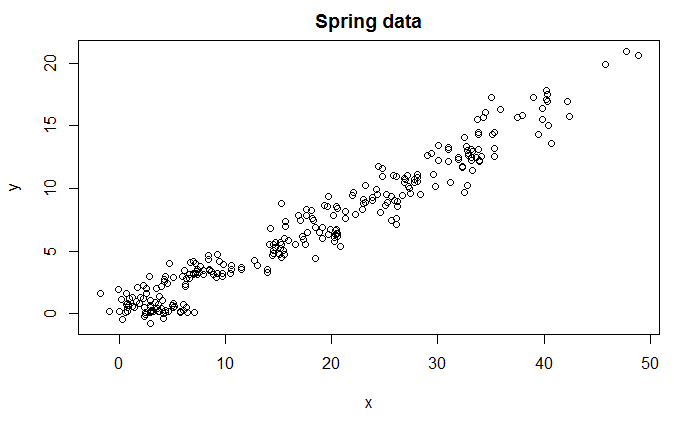

```r
  y <- data.sp$y
  x <- data.sp$x
  z <- data.sp$z
  e <- data.sp$e
  plot(x, y, main="Spring data")
```

```r
  mod <- lm(y ~ x + I(x^2) + z + e)
  sum_mod <- summary(mod)
  sum_mod
```

```
Call:
lm(formula = y ~ x + I(x^2) + z + e)

Residuals:
    Min      1Q  Median      3Q     Max
-3.4485 -0.5835  0.0275  0.6108  3.0555

Coefficients:
              Estimate Std. Error t value Pr(>|t|)
(Intercept)  1.3912960  0.6057629   2.297   0.0224 *
x            0.0161196  0.0289591   0.557   0.5782
I(x^2)       0.0044027  0.0004296  10.248   <2e-16 ***
z            0.0450444  0.0036368  12.386   <2e-16 ***
e           -0.0013999  0.0004923  -2.843   0.0048 **
---
Signif. codes:  0 ‘***’ 0.001 ‘**’ 0.01 ‘*’ 0.05 ‘.’ 0.1 ‘ ’ 1

Residual standard error: 0.9262 on 271 degrees of freedom
Multiple R-squared:  0.9678,    Adjusted R-squared:  0.9673
F-statistic:  2036 on 4 and 271 DF,  p-value: < 2.2e-16
```

#### Model diagnostics

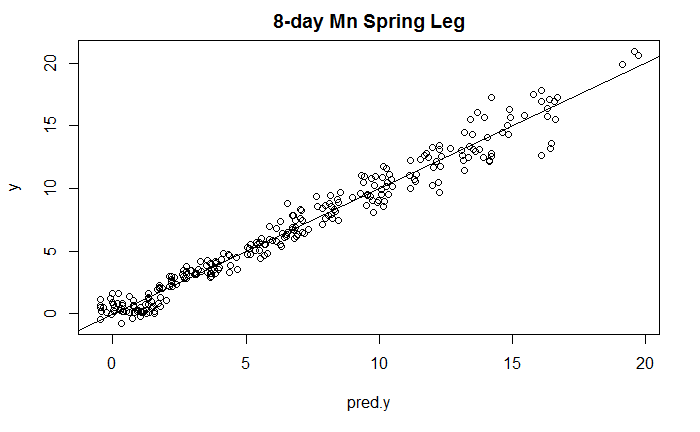

```r
  pred.y <- predict(mod)
  pred.y[pred.y < -0.5] = -0.5
  {plot(pred.y, y, main = paste0("8-day ", var, " Spring Leg"))
  abline(0,1)}
```

Test assumption of linear model

```r
  post_mod <- summary(lm(y ~ pred.y))
  gvmodel <- gvlma(mod)
  summary(gvmodel)
```

```
Call:
lm(formula = y ~ x + I(x^2) + z + e)

Residuals:
    Min      1Q  Median      3Q     Max
-3.4485 -0.5835  0.0275  0.6108  3.0555

Coefficients:
              Estimate Std. Error t value Pr(>|t|)
(Intercept)  1.3912960  0.6057629   2.297   0.0224 *
x            0.0161196  0.0289591   0.557   0.5782
I(x^2)       0.0044027  0.0004296  10.248   <2e-16 ***
z            0.0450444  0.0036368  12.386   <2e-16 ***
e           -0.0013999  0.0004923  -2.843   0.0048 **
---
Signif. codes:  0 ‘***’ 0.001 ‘**’ 0.01 ‘*’ 0.05 ‘.’ 0.1 ‘ ’ 1

Residual standard error: 0.9262 on 271 degrees of freedom
Multiple R-squared:  0.9678,    Adjusted R-squared:  0.9673
F-statistic:  2036 on 4 and 271 DF,  p-value: < 2.2e-16


ASSESSMENT OF THE LINEAR MODEL ASSUMPTIONS
USING THE GLOBAL TEST ON 4 DEGREES-OF-FREEDOM:
Level of Significance =  0.05

Call:
 gvlma(x = mod)

                       Value   p-value                   Decision
Global Stat        54.724599 3.711e-11 Assumptions NOT satisfied!
Skewness            2.787199 9.502e-02    Assumptions acceptable.
Kurtosis           13.636951 2.218e-04 Assumptions NOT satisfied!
Link Function       0.002997 9.563e-01    Assumptions acceptable.
Heteroscedasticity 38.297451 6.074e-10 Assumptions NOT satisfied!
```

check for outliers

```r
  outlierTest(mod)
```

```
     rstudent unadjusted p-value Bonferonni p
269 -3.865738         0.00013881     0.038311
```

rerun w/o outliers

```r
  mod <- lm(y ~ x + I(x^2) + z + e, data=data.sp[-c(247,269), ])
```

plot model diagnostics

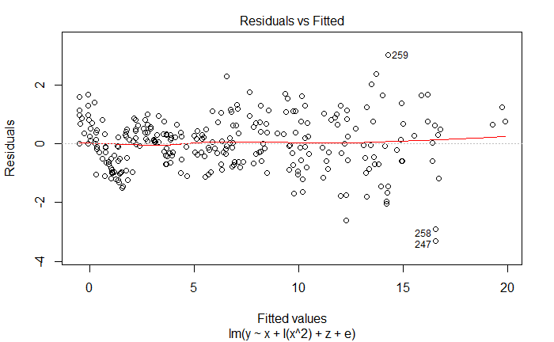

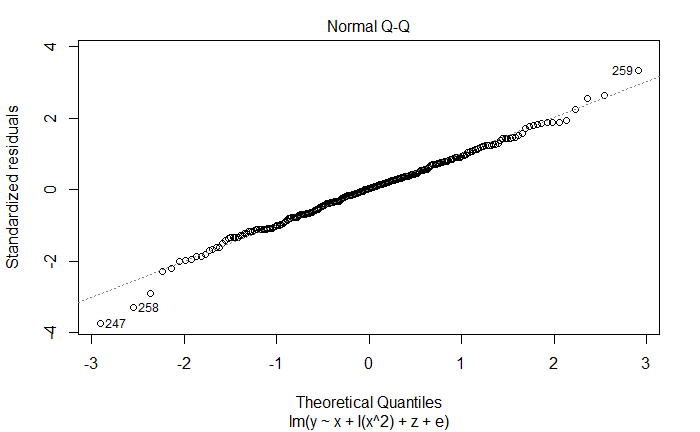

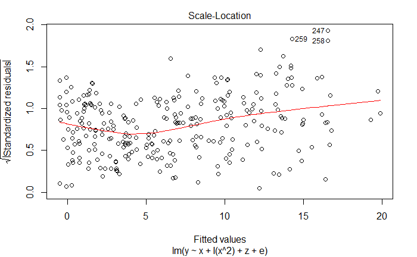

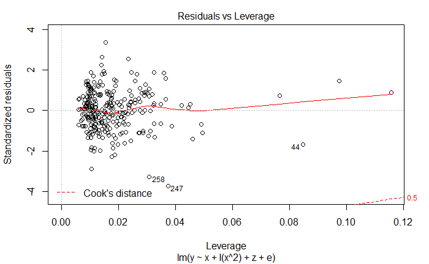

```r
  plot(mod)
```

recheck for outliers

```r
  outlierTest(mod)
```

```
No Studentized residuals with Bonferonni p < 0.05
Largest |rstudent|:
     rstudent unadjusted p-value Bonferonni p
258 -3.574672          0.0004158      0.11393
```

recheck assumptions

```r
  gvmodel <- gvlma(mod)
  summary(gvmodel)
```

```
Call:
lm(formula = y ~ x + I(x^2) + z + e, data = data.sp[-c(247, 269),
    ])

Residuals:
     Min       1Q   Median       3Q      Max
-3.03388 -0.60313  0.02673  0.56996  2.93943

Coefficients:
              Estimate Std. Error t value Pr(>|t|)
(Intercept)  1.4556989  0.5769121   2.523  0.01220 *
x            0.0053836  0.0276409   0.195  0.84572
I(x^2)       0.0047365  0.0004133  11.461  < 2e-16 ***
z            0.0453300  0.0034683  13.070  < 2e-16 ***
e           -0.0014283  0.0004690  -3.046  0.00255 **
---
Signif. codes:  0 ‘***’ 0.001 ‘**’ 0.01 ‘*’ 0.05 ‘.’ 0.1 ‘ ’ 1

Residual standard error: 0.8813 on 269 degrees of freedom
Multiple R-squared:  0.9707,    Adjusted R-squared:  0.9703
F-statistic:  2231 on 4 and 269 DF,  p-value: < 2.2e-16


ASSESSMENT OF THE LINEAR MODEL ASSUMPTIONS
USING THE GLOBAL TEST ON 4 DEGREES-OF-FREEDOM:
Level of Significance =  0.05

Call:
 gvlma(x = mod)

                      Value   p-value                   Decision
Global Stat        28.70872 8.958e-06 Assumptions NOT satisfied!
Skewness            0.17865 6.725e-01    Assumptions acceptable.
Kurtosis            3.09053 7.875e-02    Assumptions acceptable.
Link Function       0.09794 7.543e-01    Assumptions acceptable.
Heteroscedasticity 25.34159 4.802e-07 Assumptions NOT satisfied!
```

more tests: qqplot

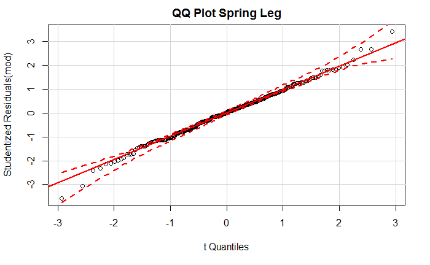

```r
  qqPlot(mod, main="QQ Plot Spring Leg")
```

if outliers need to be removed (otherwise skip)

```r
  data.sp <- data.sp[-c(247,269), ]
  y <- data.sp$y
  x <- data.sp$x
  z <- data.sp$z
  e <- data.sp$e
  mod <- lm(y ~ x + I(x^2) + z + e)
  sum_mod <- summary(mod)
```

format the data for prediction output

```r
  pressstat_sum <- PRESS(sum_mod, verbose = "FALSE")

  coeffs <- as.matrix(coefficients(mod))
  pred.y <- predict(mod)

  pred.y[pred.y < -0.5] = -0.5
```

Look at the residuals

```
11 negative fitted values removed
```

```
Suggested power transformation:  0.8807403
```

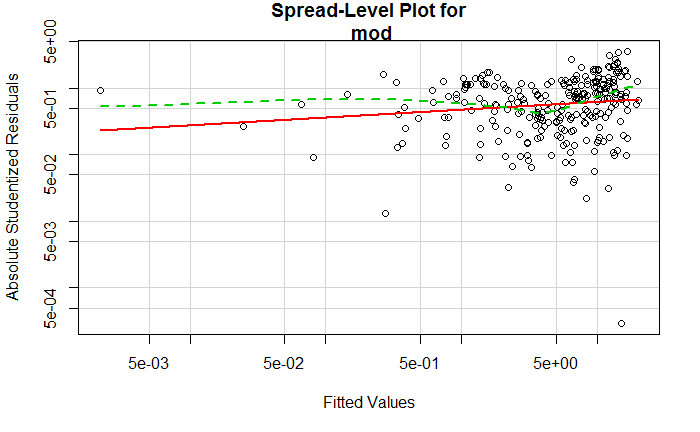

```r
  spreadLevelPlot(mod)
```

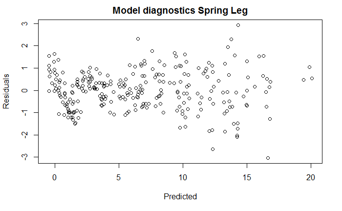

```r
  plot(pred.y, mod$residuals, main="Model diagnostics Spring Leg", xlab="Predicted", ylab="Residuals")
```

LOO PRESS stats

```r
  pressstat_sum <- PRESS(sum_mod, verbose = "FALSE")
  RMSEP <- sqrt(mean((pressstat_sum$residuals)^2))

  library(pls)
  mod2 <- plsr(y ~ x + I(x^2) + z +e, validation = "LOO")
  p2 <- R2(mod2)
  detach("package:pls", unload=TRUE)
```

write out predicted, coeffs, & metrics

```r
  pred.out <- matrix(nrow=length(pred.y), ncol=5)
  pred.out[,1] <- y
  pred.out[,2] <- pred.y
  pred.out[,3] <- z
  pred.out[,4] <- "Spring"
  pred.out[,5] <- yearPath
  colnames(pred.out) <- c("Y", "PredY", "JulDay", "Season", "Year")
  write.table (x=pred.out,append=F,row.names=F,file=paste0("jk_pred_v_y_", var, "_", basin, "_", yearPath, "_sp_fall.csv"),sep = ",", col.names=F)

  coeffs_out[1,1] <- coeffs[1,1]
  coeffs_out[1,2] <- coeffs[2,1]
  coeffs_out[1,3] <- coeffs[3,1]
  coeffs_out[1,4] <- coeffs[4,1]
  coeffs_out[1,5] <- coeffs[5,1]

  metrics_out[1,1] <- sum_mod$adj.r.squared
  metrics_out[1,2] <- sum_mod$sigma
  metrics_out[1,3] <- p2$val[5]
  metrics_out[1,4] <- RMSEP
  metrics_out[1,5] <- length(unique(data.sp$SiteName))
  metrics_out[1,6] <- length(y)
```

Fall data model

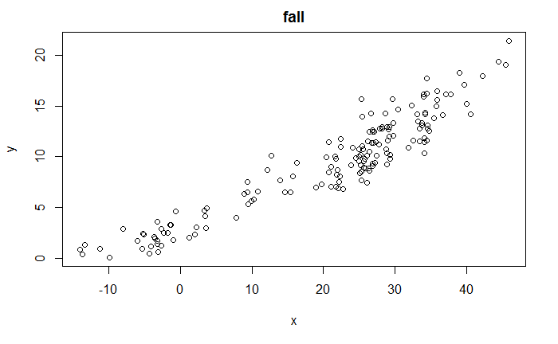

```r
  y <- data.fall$y
  x <- data.fall$x
  z <- data.fall$z
  e <- data.fall$e
  plot(x, y, main="fall")
```

```r
  mod <- lm(y ~ x + I(x^2) + z +e)
  sum_mod <- summary(mod)
  sum_mod
```

```
Call:
lm(formula = y ~ x + I(x^2) + z + e)

Residuals:
    Min      1Q  Median      3Q     Max
-3.1403 -0.9488  0.0389  1.0089  3.9748

Coefficients:
              Estimate Std. Error t value Pr(>|t|)
(Intercept) 22.6083479  3.3429757   6.763 2.56e-10 ***
x            0.1197792  0.0274325   4.366 2.29e-05 ***
I(x^2)       0.0019870  0.0006093   3.261  0.00136 **
z           -0.0444418  0.0078471  -5.663 6.95e-08 ***
e           -0.0039852  0.0008794  -4.532 1.16e-05 ***
---
Signif. codes:  0 ‘***’ 0.001 ‘**’ 0.01 ‘*’ 0.05 ‘.’ 0.1 ‘ ’ 1

Residual standard error: 1.433 on 156 degrees of freedom
Multiple R-squared:  0.9111,    Adjusted R-squared:  0.9088
F-statistic: 399.8 on 4 and 156 DF,  p-value: < 2.2e-16
```